# Checkpoint1

Arthur Sena

04/29/2016

# Descrição dos Dados

Os dados para realizar a predição foram extraídos do portal www.qmrepresenta.com.br, onde são elencados votações polêmicas da câmara dos deputados e que repercutiram na mídia nacional.

O dataset é composto de 540 observações e 25 variáveis, onde a variável IMPEACHMENT será nossa variável resposta. São elas:

**id_dep:** identificador do deputado (é o mesmo identificador para a api da câmara. Ver http://www.camara.leg.br)

**nome:** Nome do deputado sem acentos, pontuações ou espaços.

**nome_ completo:** Nome completo do deputado

**partido:** legenda do partido

**UF:** estado que o deputado foi eleito

__tema_*:__ variáveis referentes as votações que constam no portal “Quem me Representa”

**IMPEACHMENT:** voto do impeachment. (variável resposta)

Abaixo é possível visualizar uma pequena amostra dos nossos dados.

```r
    library(GGally)
    library(caret)
    library(C50)
    library(dplyr)
    set.seed(46)
    temas <- read.delim("~/Documents/DataAnalysis_Problems/DataCourse2/Problem5/temas.csv")
    imp.votacao <- read.csv("~/Documents/DataAnalysis_Problems/DataCourse2/Problem5/imp-votacao.csv")
    deputados_temas_e_impeachment_v1.1 <- read.csv("~/Documents/DataAnalysis_Problems/DataCourse2/Problem5/deputados_temas_e_impeachment_v1.1.csv", sep=";")

    head(imp.votacao)
```

```
##                   deputado partido estado voto
## 1             Pedro Vilela    PSDB     AL  SIM
## 2 Maurício Quintella Lessa      PR     AL  SIM
## 3             Marx Beltrão    PMDB     AL  SIM
## 4                      JHC     PSB     AL  SIM
## 5           Cícero Almeida    PMDB     AL  SIM
## 6              Arthur Lira      PP     AL  SIM
```

```r
    head(deputados_temas_e_impeachment_v1.1)
```

```
##   id_dep                nome             deputado partido UF tema_1
## 1 178864       AdailCarneiro       Adail Carneiro     phs CE    sim
## 2 178914 AdalbertoCavalcanti Adalberto Cavalcanti     ptb PE    sim
## 3 178890  AdelmoCarneiroLeao Adelmo Carneiro Leão      pt MG     não
## 4 178968      AdelsonBarreto      Adelson Barreto     ptb SE    sim
## 5 178903     AdiltonSachetti     Adilton Sachetti     psb MT    sim
## 6 141372       AeltonFreitas       Aelton Freitas      pr MG    sim
##      tema_2 tema_3 tema_4 tema_5 tema_6 tema_7 tema_8   tema_9 tema_10
## 1       sim    sim    sim     não     não    sim    sim      sim     sim
## 2       sim    sim    sim    sim    sim    sim    sim não votou     sim
## 3       sim    sim     não     não     não     não     não       não      não
## 4 não votou    sim    sim    sim    sim    sim    sim      sim     sim
## 5        não    sim    sim    sim    sim    sim    sim      sim      não
## 6       sim    sim    sim    sim    sim    sim    sim      sim      não
##    tema_11 tema_12 tema_13  tema_14  tema_15 tema_16 tema_17  tema_18
## 1      sim     sim      não      sim       não     sim      não      sim
## 2 não votou     sim     sim não votou não votou     sim     sim      sim
## 3       não     sim     sim      sim      sim     sim      não não votou
## 4       não     sim     sim       não       não     sim     sim      sim
## 5      sim     sim      não      sim       não     sim     sim      sim
## 6      sim     sim     sim      sim      sim     sim      não      sim
##    tema_19 IMPEACHMENT
## 1       não         SIM
## 2      sim         NAO
## 3 não votou         NAO
## 4      sim         SIM
## 5      sim         SIM
## 6      sim         NAO
```

```r
     deputados_temas_e_impeachment_v1.1$IMPEACHMENT <- as.character(deputados_temas_e_impeachment_v1.1$IMPEACHMENT)
      deputados_temas_e_impeachment_v1.1 <- filter(deputados_temas_e_impeachment_v1.1, as.character(IMPEACHMENT) != "ABST", as.character(IMPEACHMENT) != "AUSEN")
      deputados_temas_e_impeachment_v1.1$IMPEACHMENT <- as.factor(deputados_temas_e_impeachment_v1.1$IMPEACHMENT)
```

Obs.: Eu precisei eliminar os deputados que estiveram ausente ou que se abstiveram, pois o caret reclama que não pode usar o glm pra classificar uma variável que apresenta mais que dois níveis. Ou seja, apenas deixei os deputados que votaram SIM ou NÃO.

Vamos analisar a frequência dos votos.

```r
    table(deputados_temas_e_impeachment_v1.1$IMPEACHMENT)
```

```
##
## NAO SIM
## 135 360
```

Vamos agora ver como as nossas variáveis se relacionam com a variável alvo.

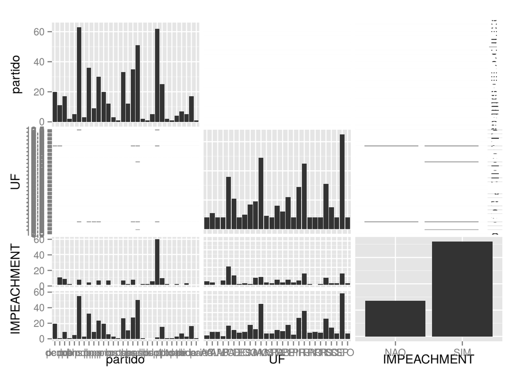

```r
   ggpairs(deputados_temas_e_impeachment_v1.1[,c(4,5,25)])
```

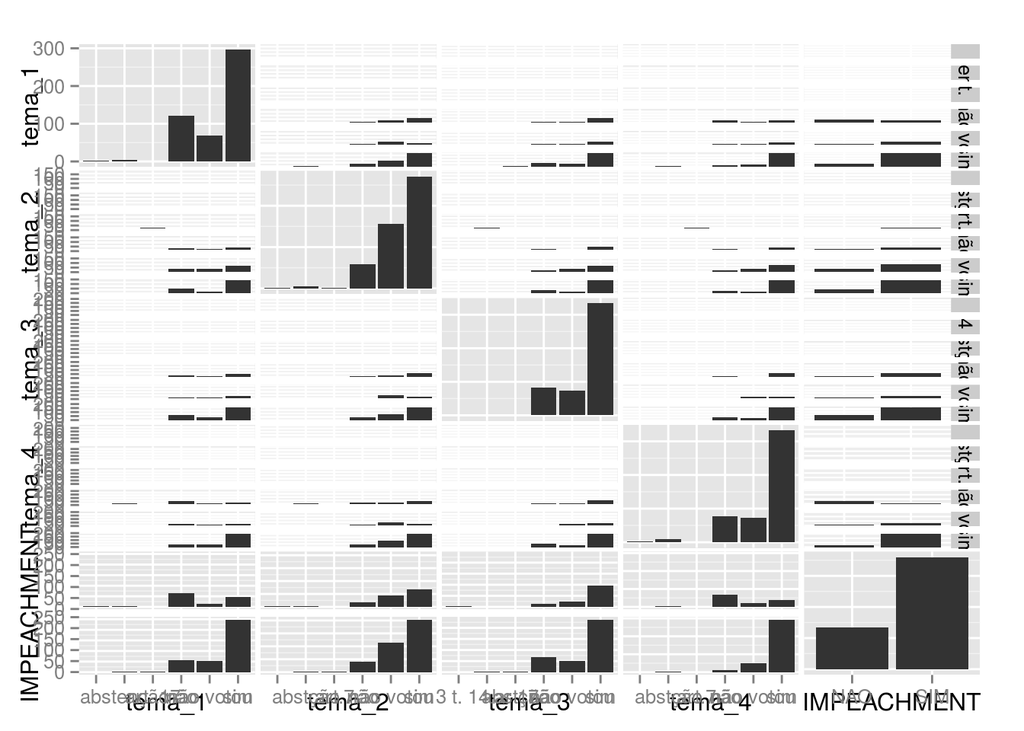

```r
   ggpairs(deputados_temas_e_impeachment_v1.1[,c(6,7,8,9,25)])
```

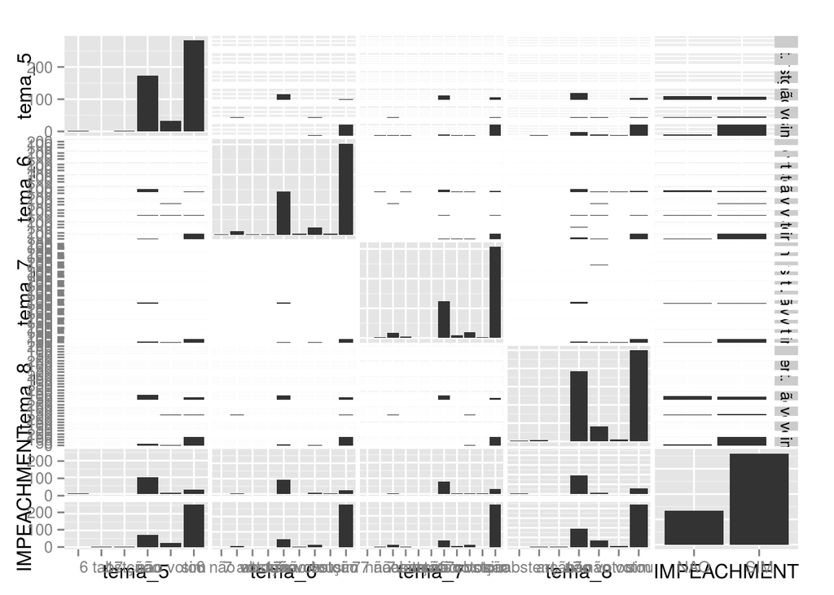

```r
   ggpairs(deputados_temas_e_impeachment_v1.1[,c(10,11,12,13,25)])
```

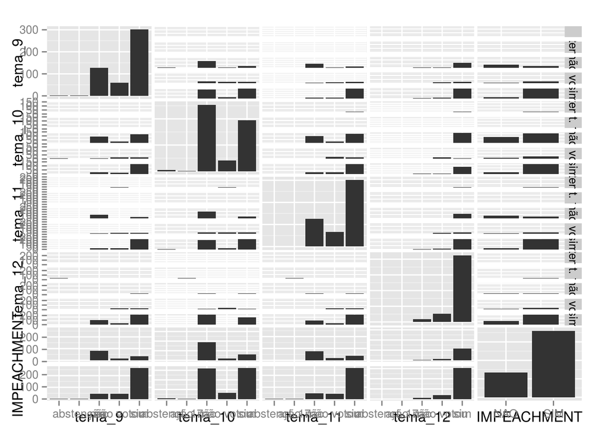

```r
   ggpairs(deputados_temas_e_impeachment_v1.1[,c(14,15,16,17,25)])
```

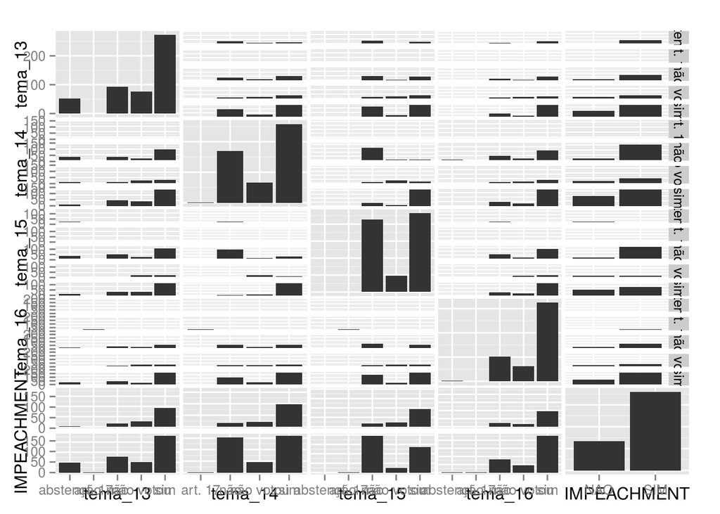

```r
   ggpairs(deputados_temas_e_impeachment_v1.1[,c(18,19,20,21,25)])
```

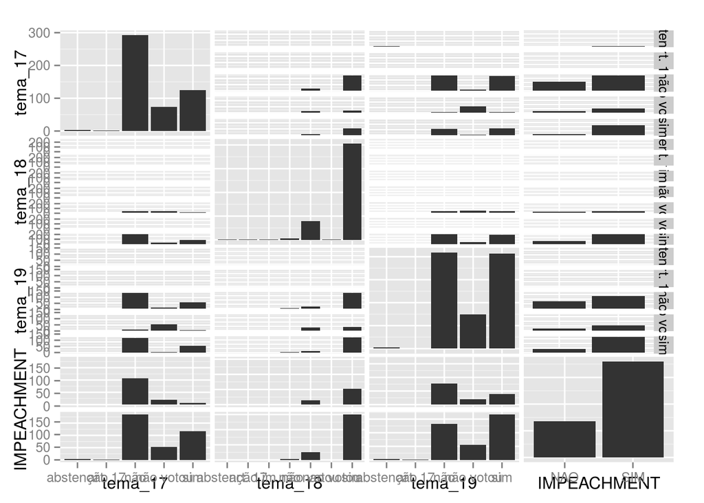

```r
   ggpairs(deputados_temas_e_impeachment_v1.1[,c(22,23,24,25)])
```

# Treinando o modelo (regressão-logistica)

```r
      trainIndex <- createDataPartition(deputados_temas_e_impeachment_v1.1$IMPEACHMENT, p = .75,
                                  list = FALSE,
                                  times = 1)

      train <- deputados_temas_e_impeachment_v1.1[trainIndex,]
      test <-  deputados_temas_e_impeachment_v1.1[-trainIndex,]
       ctrl <- trainControl(method = "repeatedcv", number = 10,repeats=10, savePredictions = TRUE)
      logit <- train(IMPEACHMENT ~ ., method='glm', family='binomial', data=train[,4:25], trControl = ctrl)
```

# Importância das variáveis.

```r
   (varImp(logit))
```

```
## glm variable importance
##
##   only 20 most important variables shown (out of 118)
##
##                  Overall
## UFRR              100.00
## UFTO               90.05
## UFPR               75.75
## UFRS               73.64
## partidopdt         69.90
## UFRN               67.83
## UFMS               63.78
## `tema_4não`         62.00
## UFRJ               59.65
## UFPE               58.95
## UFSE               56.16
## `tema_9não votou`   55.13
## UFPA               55.08
## UFSC               53.35
## partidopsol        49.17
## `tema_6não`         46.66
## `tema_7não`         43.95
## partidopsl         43.90
## UFGO               42.41
## UFAP               42.17
```

# Testando o modelo (regressão-logistica)

```r
      confusionMatrix(test$IMPEACHMENT, predict(logit, test[,4:24]))
```

```
## Confusion Matrix and Statistics
##
##           Reference
## Prediction NAO SIM
##        NAO  22  11
##        SIM  16  74
##
##                Accuracy : 0.7805
##                  95% CI : (0.6969, 0.8501)
##     No Information Rate : 0.6911
##     P-Value [Acc > NIR] : 0.01798
##
##                   Kappa : 0.4665
##  Mcnemar's Test P-Value : 0.44142
##
##             Sensitivity : 0.5789
##             Specificity : 0.8706
##          Pos Pred Value : 0.6667
##          Neg Pred Value : 0.8222
##              Prevalence : 0.3089
##          Detection Rate : 0.1789
##    Detection Prevalence : 0.2683
##       Balanced Accuracy : 0.7248
##
##        'Positive' Class : NAO
##
```

# Engenharia de Features

Podemos tentar melhorar nosso modelo apenas adicionando variáveis que possam ajudá-lo. Por exemplo, segundo essa [notícia](http://www.gazetadopovo.com.br/blogs/caixa-zero/93-dos-deputados-da-bancada-evangelica-votaram-pelo-impeachment/) 93% dos deputados da bancada evangélica votaram pelo impeachment. Desse modo, uma variável que pudesse dizer se o deputado é ou não evangélico poderia ajudar o modelo.

Pensando nisso, eu achei esse [link](http://noticias.gospelmais.com.br/lista-deputados-evangelicos-favor-contra-impeachment-82156.html) que contém a lista dos deputados evangélicos, e a partir disso, fiz um script em python que cria a coluna “evangelico”. O script pode ser visualizado logo abaixo:

```r
#!/usr/bin/env python
import sys

reload(sys)
sys.setdefaultencoding('utf8')

f = open('deputados_temas_e_impeachment_v1.1.csv','r')

evang = open('deput_evang_lista.txt','r')

lista_evang = []
for nome in evang.readlines():
    nome_formatado = (nome.strip()).split(" ")[0:2]
        if "(" not in nome_formatado[1]:
            temp1 = nome_formatado[0]
            temp2 = nome_formatado[1]
            nome_sobrenome = temp1 + temp2
            nome_sobrenome
            lista_evang.append(nome_sobrenome)
        else:
            temp1 = nome_formatado[0]
            nome_sem_sobrenome = temp1
            lista_evang.append(nome_sem_sobrenome)

for line in f.readlines():
    nome_deputado  =  (line.strip()).split(";")[1]
    if "id_dep" in (line.strip()).split(";"):
        print (line.strip()) + ";" + "evangelico"
    elif nome_deputado.upper() in lista_evang:
        print (line.strip()) + ";" + "sim"
    else:
        print (line.strip()) + ";" + "nao"
```

Agora vamos importar o nosso novo dataset.

```r
     deputados_impeachment_evang <- read.csv("~/Documents/DataAnalysis_Problems/DataCourse2/Problem5/deputados_impeachment_evang.csv", sep=";")

   #Reordenando as colunas
   deputados_impeachment_evang <- deputados_impeachment_evang[c(1,2,3,4,5,6,7,8,9,10,11,12,13,14,15,16,17,18,19,20,21,22,23,24,26,25)]

   #Removendo deputados que se absteram-se ou estavam ausentes

     deputados_impeachment_evang$IMPEACHMENT <- as.character(deputados_impeachment_evang$IMPEACHMENT)
deputados_impeachment_evang <- filter(deputados_impeachment_evang, as.character(IMPEACHMENT) != "ABST", as.character(IMPEACHMENT) != "AUSEN")
      deputados_impeachment_evang$IMPEACHMENT <- as.factor(deputados_impeachment_evang$IMPEACHMENT)
```

Vamos analisar a relação da nossa nova variavel com o target.

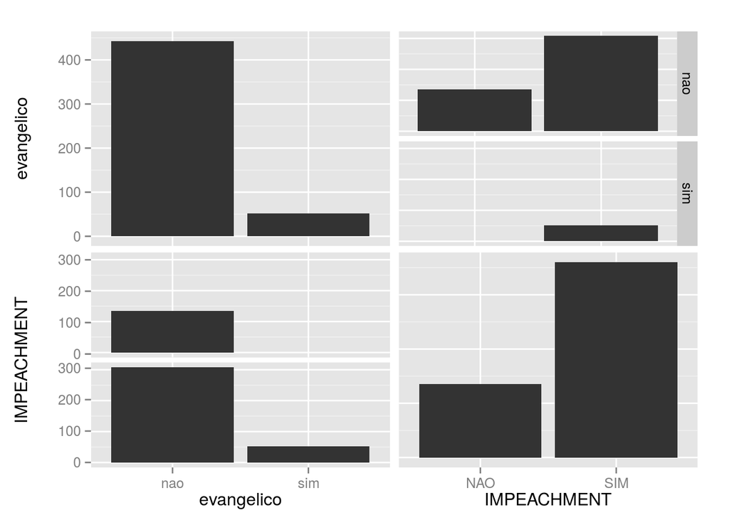

```r
      ggpairs(deputados_impeachment_evang[,c(25,26)])
```

Vemos que todos os deputados que marcamos como evangéligos votaram a favor do impeachment, ou seja, nossa nova variável tem uma boa relação com o alvo.

# Treinando modelo (usando variavel “evangelico”)

```r
     trainIndex <- createDataPartition(deputados_impeachment_evang$IMPEACHMENT, p = .75,
                                  list = FALSE,
                                  times = 1)

      train <- deputados_impeachment_evang[trainIndex,]
      test <-  deputados_impeachment_evang[-trainIndex,]

      logit2 <- train(IMPEACHMENT ~ ., method='glm', family='binomial', data=train[,4:26], trControl = ctrl)
```

# Importância das variáveis.

```r
   varImp(logit2)
```

```
## glm variable importance
##
##   only 20 most important variables shown (out of 118)
##
##                  Overall
## partidopsl        100.00
## partidopt          84.39
## partidorede        78.00
## partidopsol        75.27
## partidoprp         73.59
## partidopsd         73.31
## partidopr          69.22
## partidopcdob       68.34
## partidopdt         67.21
## `tema_15não`        65.69
## UFBA               63.41
## partidopp          60.22
## partidopsdb        57.21
## UFAP               55.90
## UFRN               54.97
## partidopros        54.96
## UFTO               53.19
## partidoptb         52.23
## `tema_9não votou`   51.47
## evangelicosim      51.00
```

Vemos que a nova variável se encontra entre as vinte mais importantes. O que é um bom sinal.

# Testando o modelo (usando variavel “evangelico”)

```r
    confusionMatrix(test$IMPEACHMENT, predict(logit2, test[,4:25]))
```

```
## Confusion Matrix and Statistics
##
##           Reference
## Prediction NAO SIM
##        NAO  24   9
##        SIM  14  76
##
##                Accuracy : 0.813
##                  95% CI : (0.7328, 0.8776)
##     No Information Rate : 0.6911
##     P-Value [Acc > NIR] : 0.001621
##
##                   Kappa : 0.5455
##  Mcnemar's Test P-Value : 0.404248
##
##             Sensitivity : 0.6316
##             Specificity : 0.8941
##          Pos Pred Value : 0.7273
##          Neg Pred Value : 0.8444
##              Prevalence : 0.3089
##          Detection Rate : 0.1951
##    Detection Prevalence : 0.2683
##       Balanced Accuracy : 0.7628
##
##        'Positive' Class : NAO
##
```

Observando os resultados, vemos que conseguimos melhorar a acurácia do nosso modelo usando a variável nova.

Outro fato interessante sobre os nossos deputados é que quase 60% dos que votaram contra o governo apresentam alguma pendência na justiça segundo esse [link](http://www.ebc.com.br/noticias/politica/2016/04/cerca-60-dos-deputados-federais-que-julgaram-dilma-tem-pendencias-na). O mesmo link apresenta uma lista dos deputados.

Desse modo, vamos criar outra variável que diga se o deputado tem uma pendência judicial ou não. Para isso, novamente precisei criar um script em python que pudesse me ajudar. O código pode ser visto abaixo.

```r
#!/usr/bin/env python
import sys

reload(sys)
sys.setdefaultencoding('utf8')

from unidecode import unidecode

f = open('deputados_impeachment_evang.csv','r')

deput_pend_jud = open('deput_pend_jud.txt','r')


lista_pend = []
for line in deput_pend_jud.readlines():
  temp = line.strip().split("\t")
    if len(temp) > 1:
        if len(temp[0].split(" ")) == 2:
            lista_pend.append("".join(temp[0].split(" ")))
        elif len(temp[0].split(" ")) > 2:
            nome1 = temp[0].split(" ")[0]
            nome2 = temp[0].split(" ")[1]
            lista_pend.append(nome1 + nome2)

for line in f.readlines():
    nome_deputado  =  (line.strip()).split(";")[1]
    if "id_dep" in (line.strip()).split(";"):
        print (line.strip()) + ";" + "pendencia"
    elif nome_deputado.upper() in lista_pend:
        print (line.strip()) + ";" + "sim"
    else:
        print (line.strip()) + ";" + "nao"
```

Com a nova coluna criada, vamos repetir o processo de construção e teste do modelo.

```r
    deputados_impeachment_evang_pend <- read.csv("~/Documents/DataAnalysis_Problems/DataCourse2/Problem5/deputados_impeachment_evang_pend.csv", sep=";")

    deputados_impeachment_evang_pend <- deputados_impeachment_evang_pend[c(1,2,3,4,5,6,7,8,9,10,11,12,13,14,15,16,17,18,19,20,21,22,23,24,26,27,25)]
      deputados_impeachment_evang_pend <- select(deputados_impeachment_evang_pend, -evangelico)
      deputados_impeachment_evang_pend$IMPEACHMENT <- as.character(deputados_impeachment_evang_pend$IMPEACHMENT)
      deputados_impeachment_evang_pend <- filter(deputados_impeachment_evang_pend, as.character(IMPEACHMENT) != "ABST", as.character(IMPEACHMENT) != "AUSEN")
      deputados_impeachment_evang_pend$IMPEACHMENT <- as.factor(deputados_impeachment_evang_pend$IMPEACHMENT)
```

# Relação da variável com o alvo

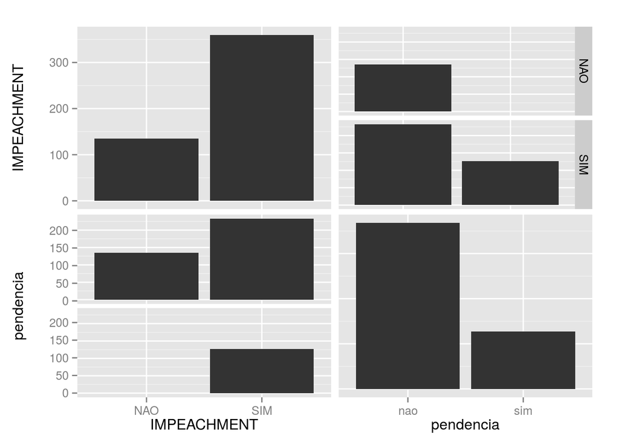

```r
   ggpairs(deputados_impeachment_evang_pend[,c(26,25)])
```

Todos os deputados que apresentam pendências judiciais votaram sim. Isso é um bom indicador de que estamos no caminho certo.

# Treinando o modelo (usando variavel “pendência judicial”)

```r
      trainIndex <- createDataPartition(deputados_impeachment_evang_pend$IMPEACHMENT, p = .75,
                                  list = FALSE,
                                  times = 1)

      train <- deputados_impeachment_evang_pend[trainIndex,]
      test <-  deputados_impeachment_evang_pend[-trainIndex,]

      logit3 <- train(IMPEACHMENT ~ ., method='glm', family='binomial', data=train[,4:26], trControl = ctrl)
```

# Importância das variáveis

```r
    varImp(logit3)
```

```
## glm variable importance
##
##   only 20 most important variables shown (out of 120)
##
##                   Overall
## partidopdt         100.00
## pendenciasim        98.59
## UFRJ                96.99
## UFRS                89.64
## partidopt           87.24
## `tema_18não votou`   82.99
## UFGO                82.02
## `tema_15não`         80.76
## `tema_6não`          79.52
## UFPR                75.82
## UFAL                74.76
## UFSC                69.31
## `tema_16não`         65.17
## `tema_8não votou`    62.53
## UFSP                60.63
## partidopr           59.01
## partidos.part.      57.41
## UFRR                56.45
## partidoptb          54.48
## partidopp           53.64
```

Vemos que a variável ‘penência’ se encontra entre as mais importantes. Vamos agora testar.

# Testando o modelo (usando variavel “pendência judicial”)

```r
   confusionMatrix(test$IMPEACHMENT, predict(logit3, test[,4:25]))
```

```
## Confusion Matrix and Statistics
##
##           Reference
## Prediction NAO SIM
##        NAO  26   7
##        SIM  12  78
##
##                Accuracy : 0.8455
##                  95% CI : (0.7693, 0.9044)
##     No Information Rate : 0.6911
##     P-Value [Acc > NIR] : 6.58e-05
##
##                   Kappa : 0.6246
##  Mcnemar's Test P-Value : 0.3588
##
##             Sensitivity : 0.6842
##             Specificity : 0.9176
##          Pos Pred Value : 0.7879
##          Neg Pred Value : 0.8667
##              Prevalence : 0.3089
##          Detection Rate : 0.2114
##    Detection Prevalence : 0.2683
##       Balanced Accuracy : 0.8009
##
##        'Positive' Class : NAO
##
```

Novamente, conseguimos aumentar a acurácia em relação ao primeiro modelo criado.